# Reallocation effects of the minimum wage

Quarterly Journal of Economics, Volume 137, Issue 1, February 2022: 267–328

by Christian Dustmann, Attila Lindner, Uta Schönberg, Matthias Umkehrer, Philipp vom Berge

2022年04月12日 14:46

# Summary

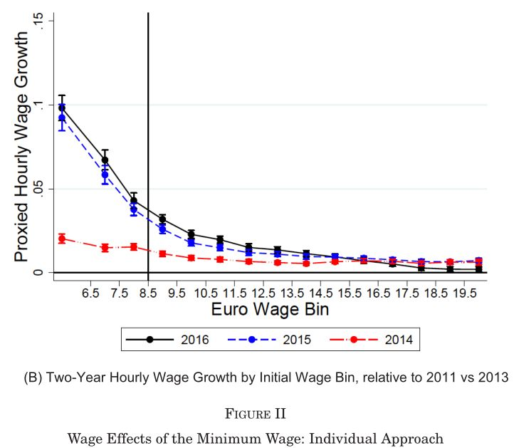

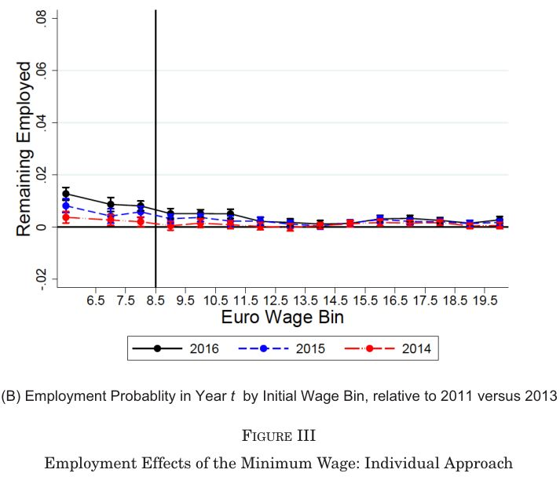

- German minimum wage of 2015 increased wages but did not reduce employment.
- Absence of disemployment is due to reallocation of workers from low-wage paying firms to high-wage paying firms.
- This reduced the wage inequality at the lower tail of distribution.
- Low-wage paying firms are small establishments with lower productivity.
- Higher-wage paying firms are more efficient firms.
- Therefore, on average, minimum wage introduction increased the worker welfare and allocative efficiency of workers.
- Workers commute longer hours for higher wages, especially males.
- Outcomes are consistent with monopolistic competition in labour markets.
- First to show allocative/efficiency effects of minimum wages without structural estimation.

# Intro

## Context

Jan 2015: Uniform €8.50/hour with 15% of workers earning below it.  
Unemployed in prev year, work shorter hours, hired at small establishments.  
MW/Median wage = .48 (.36 US; .61 France).

- Economists: Minimum wages will reduce employment by 900K.

## Existing literature

**Employment impacts of minimum wages**  
Card and Krueger (1995), Neumark and Wascher (2007), but with wider coverage and more precision

Card, David, and Alan B Krueger. 1995. “Myth and Measurement: The New Economics of the Minimum Wage.” HeinOnline.

Neumark, David, and William L. Wascher. 2007. “Minimum Wages and Employment.” *Foundations and Trends in Microeconomics* 3 (1-2): 1–182. https://doi.org/10.1561/0700000015.

**Firm exit impacts of minimum wages**  
Luca and Luca (2019)

Luca, Dara Lee, and Michael Luca. 2019. “Survival of the Fittest: The Impact of the Minimum Wage on Firm Exit.” https://www.nber.org/system/files/working_papers/w25806/w25806.pdf.

**Firm responses, theory**  
Acemoglu (2001), Bhaskar, Manning, and To (2002), Berger, Herkenhoff, and Mongey (2022)

Acemoglu, Daron. 2001. “Good Jobs Versus Bad Jobs.” *Journal of Labor Economics* 19 (1): 1–21.

Bhaskar, Venkataraman, Alan Manning, and Ted To. 2002. “Oligopsony and Monopsonistic Competition in Labor Markets.” *Journal of Economic Perspectives* 16 (2): 155–74.

Berger, David, Kyle Herkenhoff, and Simon Mongey. 2022. “Labor Market Power.” *American Economic Review* 112 (4): 1147–93.

**Macroeconomic allocation of resources across firms**  
Davis and Haltiwanger (1992)

Davis, Steven J, and John Haltiwanger. 1992. “Gross Job Creation, Gross Job Destruction, and Employment Reallocation.” *The Quarterly Journal of Economics* 107 (3): 819–63.

**German minimum wages**  
Bossler and Gerner (2020)

Bossler, Mario, and Hans-Dieter Gerner. 2020. “Employment Effects of the New German Minimum Wage: Evidence from Establishment-Level Microdata.” *ILR Review* 73 (5): 1070–94.

こういうのに関係あるよね、と書くだけで、ドイツのケース以外は結果の違いに言及しない。使える。

# Data

## Sources

**Panel of all job spells with employee information**  
*Administrative records of Federal Employment Agency’s Statistics Department*

**Panel of earnings and hours of jobs**  
*Employee Histories of the Institute for Employment Research in Nuremberg*

## Imputations

Work hours available until 2014. Proxy with mean working hours in each working time status category (full time, part time, marginal) for 2015 onwards.

Even reported work hours until 2014 are a mix of actual and contractual hours. Multiply hours by 1.19 for establishments reporting actual hours, where the latter is decided by 90% of full time workers working less than 35 hours per week. Aggregate hours are similar with GSOEP data.

NAs in working time status are imputed with Government research agency’s algorithm. NAs in education are imputed with another Gov research agency’s algorithm.

## Preparations

**Annual panel of all job spells for 2011-2016**. Only main job was chosen for individuals with more than 1 job.  
**Annual panel of all 401 districts for 2011-2016**. Wage, hours, employment for each work time category, firm characteristics.  
**Annual panel of establishments**. Appendix C uses this although not written explicitly.

# Identification

## Job spell panel

Bin wise growth (after): $\Delta_{2} y_{it}=y_{it}-y_{it-2}$
$$\begin{equation}
\Delta_{2} y_{it}=\sum_{k}\mathbb 1[b_{k-1}<w_{it-2}\leqslant b_{k}]\tilde{\gamma}_{kt}+\beta x_{it-2}+e_{it}.
\tag{1}
\end{equation}$$
Bin wise growth deviations from 2011 vs. 2013 (before-after): Robust to constant macroeconomic changes or constant mean reversal. $\delta_{kt}$ for higher wage bins are near zero, affirming this assumption.
$$\begin{equation}
\Delta_{2} y_{it}=\sum_{k}\mathbb 1[b_{k-1}<w_{it-2}\leqslant b_{k}](\gamma_{k2013}+\gamma_{kt})
+\beta x_{it-2}+e_{it}.
\tag{2}
\end{equation}$$
DID estimates for low wage bin $k$: Assumes a common trend between low $k$ and high $\kappa$ wage bins.
$$\gamma^{DID}_{kt}=\gamma_{kt}-\bar{\gamma}_{t}, \quad \bar{\gamma}_{t}=\sum_{\kappa>k}^{K}\frac{\gamma_{\kappa t}}{K-\kappa+1}.$$

- $\hat{\delta}_{\kappa t}\simeq 0$.
- $\hat{\delta}_{kt}>0$ for $t=2015$ onwards.
- Interacting bins with local unemploymen rates does not change results, so no indication of individual trends.

## District panel

Dose-response (exposure-response)
$$\begin{equation}
\begin{aligned}
Y_{rt}&=\alpha_{r}+\zeta_{t}+\sum_{\substack{\tau=2011\\ \tau\neq 2014}}^{2016}\gamma_{\tau}\overline{GAP}_{r}+\epsilon_{rt},\\
\overline{GAP}_{r}&=
\sum_{t=2011}^{2014}GAP_{rt}.
\end{aligned}
\tag{4}
\end{equation}$$
with GAP measuring percent increase necessary to achieve minimum wage $MW$ for all workers, or exposure to the $MW$ shock.
$$GAP_{rt}=\frac{\Sigma_{i\in r}h_{i}\max \{0, MW-w_{it}\}}{\Sigma_{i\in r}h_{i}w_{it}},$$
DID with district-specific (all period) linear time trend $\beta_{r}$ and time effects $\zeta_{t}$: Assumes linear trend to be constant and allows to vary across districts. Homogenous impact (can be made to be conditional on initial conditions).
$$\begin{equation}
Y_{rt}=\alpha_{r}+\zeta_{t}+\delta_{post}\overline{GAP}_{r}\times Post_{t}+\beta_{r}t+\epsilon_{rt}.
\tag{5}
\end{equation}$$

This estimator is more flexible than regular DID. This assumes post period impacts to be constant due to time effects $\zeta_{t}$. One can drop $\zeta_{t}$ and let impacts to be time variant $\delta_{post, t}$ on $\overline{GAP}_{r}\times 1[\tau=t]$.

No staggered introduction of the policy, so TWFE estimator is fine.

# Results

## Impacts on wages and employment

### Job spell panel

See the figures at the top.

### District panel

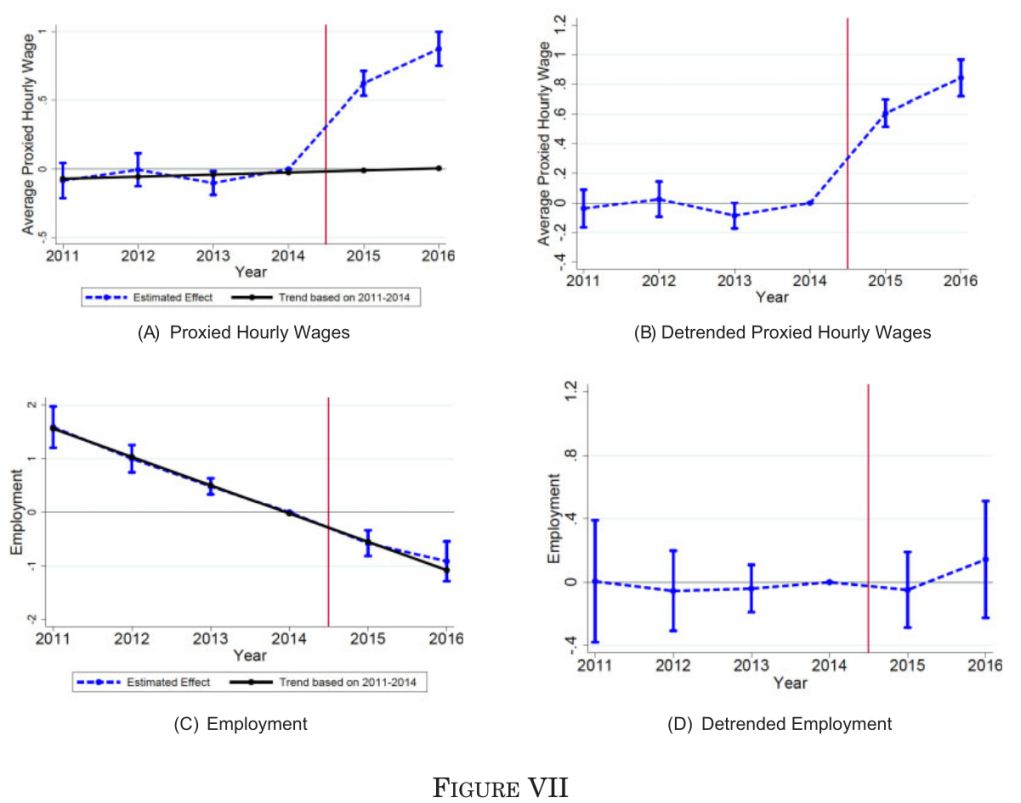

### Robustness and heterogenous impact checks

- Job spell panel and district panel both give similar results.
- Many checks, including Table VI. In Appendix C, establishment level estimation of outcome rate of change on exposure, similar to Harasztosi and Lindner (2019).

  Harasztosi, Péter, and Attila Lindner. 2019. “Who Pays for the Minimum Wage?” *American Economic Review* 109 (8): 2693–2727.

  Not sure how: ``The small negative employment effect at the establishment level does not contradict the evidence on the absence of disemployment effect at the regional and individual levels’’ (p.319).
- Using establishment level analysis, estimated labour demand elasticity is relatively small, -.26 or -.31, which is in line with previous studies (Appendix pp.65-66).

## Impacts on characteristics of hired establishment

### Job spell panel

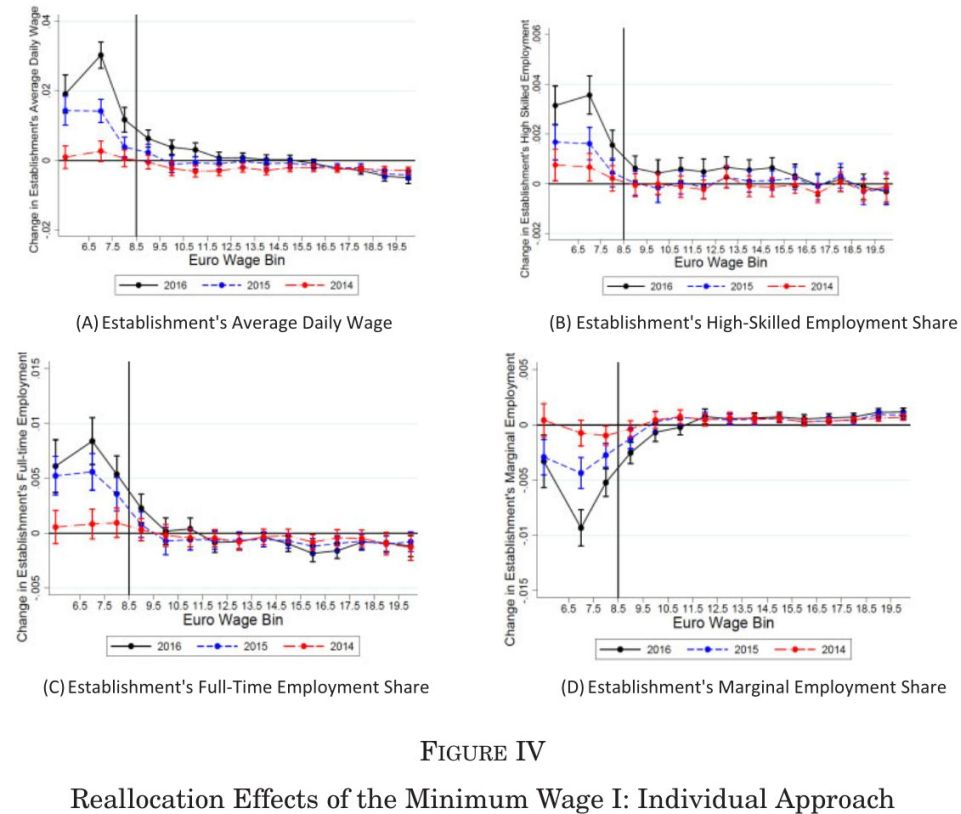

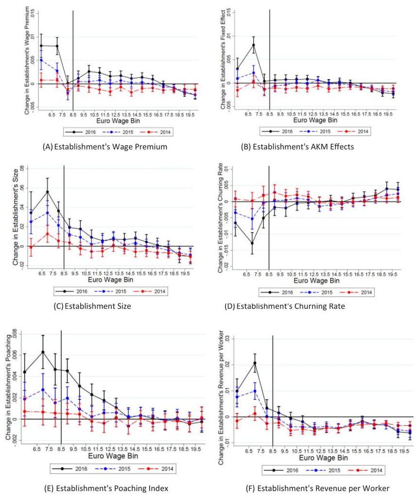

Abowd, Kramarz, and Margolis (1999) allows estimation of individual and firm fixed effects using mover data.

Abowd, John M., Francis Kramarz, and David N. Margolis. 1999. “High Wage Workers and High Wage Firms.” *Econometrica* 67 (2): 251–333.

- Basic idea: Use movers (that can eliminate worker FEs by first-differencing) to get differences of firm FEs. Set the reference firm’s FE to zero. Then impute worker FEs by subtracting estimated firm FEs from wages.
- Efficiency of this method depends on the number of movers to each firms. There are many works that expand on AKM.

### District panel

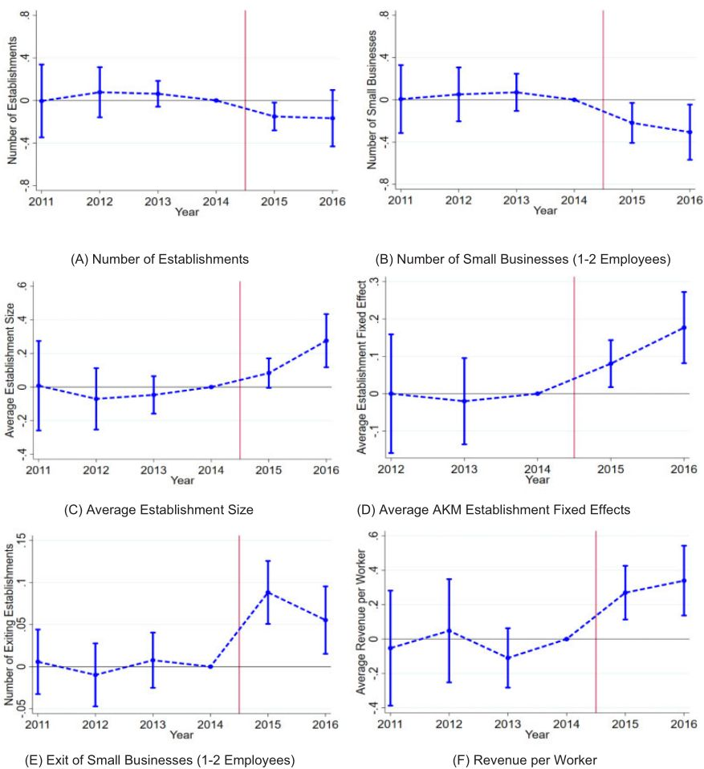

## Nonpecuniary impacts

- Absorption of workers at higher paying establishments may have come at nonpecuniary costs of workers.

Despite this, authors say (p.323):

> workers will on average be no worse off after the introduction of the minimum wage, provided that the minimum wage does not lower employment.

> the exit of inefficient firms may leave some consumers worse off despite being able to purchase similar products at a lower price. For example, some consumers may prefer nearby restaurants and shops even if they charge higher prices than restaurants and shops further away, but some of these small businesses close down after the minimum wage is implemented.

Welfare impacts are heterogenous and one cannot give a definitive answer. But authors tend to write that it improved on average.

# A model explaining results

Worker $i$ at firm $j$
$$u_{ij}=\beta \ln w_{j}+\epsilon_{ij}.$$
Worker $i$ in unemployment status
$$u_{ib}=b+\epsilon_{ib}.$$
Assuming type I extreme value distributed errors gives for the set of firms in competition $J^{M}$ and population of $N$ workers:
$$P\left[{\mbox{argmax}\atop{\scriptsize k\in J^{M}}}\{u_{ij}, u_{ib}\}=j\right]=
\frac{e^{\beta \ln w_{j}}}{e^{b}+\sum_{k\in J^{M}}\beta \ln w_{k}}=N\lambda^{M}e^{\beta \ln w_{j}}.$$
Taking logs
$$\begin{equation}
\ln l_{j}=\ln N+\ln \lambda^{M}+\beta \ln w_{j}.
\tag{D.1}
\label{D1}
\end{equation}$$
The labour supply curve in $\eqref{D1}$ is upward sloping. Similarly for unemployment probability
$$\mbox{unemployment rate}=N\lambda^{M}e^{b}.$$
Firm’s problem with productivity parameter $\phi_{j}$ and a fixed cost of hiring $F$:
$$\max_{l_{j}} \;\;\; p_{j}\frac{1}{\phi_{j}}\ln l_{j}-w_{j}l_{j}-F$$
FOC gives
$$\frac{p_{j}}{\phi_{j}}\frac{1}{l_{j}}=w_{j}\left(\frac{1+\beta}{\beta}\right), \quad \beta=\frac{dl_{j}}{dw_{j}}\frac{w_{j}}{l_{j}}.$$
Taking logs
$$\begin{equation}
\ln l_{j}=-\ln \phi_{j}+\ln\left(\frac{1+\beta}{\beta}\right)-\ln \left(\frac{w_{j}}{p_{j}}\right).
\tag{D.3}
\label{D3}
\end{equation}$$
Labour market equilibium gives
$$\begin{equation}
\ln l_{j}=\frac{1}{1+\beta}\left[\beta\ln\left(\frac{p_{j}}{\phi_{j}}\frac{\beta}{1+\beta}\right)
+\ln N+\ln \lambda^{M}\right].
\tag{D.4}
\label{D4}
\end{equation}$$
$$\begin{equation}
\ln w^{M}_{j}=\frac{1}{1+\beta}\left[\ln\left(\frac{p_{j}}{\phi_{j}}\frac{\beta}{1+\beta}\right)
-\ln N-\ln \lambda^{M}\right].
\tag{D.5}
\label{D5}
\end{equation}$$

**Predictions**

1. $\phi_{j}$ $\downarrow$ $\sim$ $l_{j}$ $\uparrow$
2. $\phi_{j}$ $\downarrow$ $\sim$ $w^{M}_{j}$ $\uparrow$
3. $\phi_{j}$ $\downarrow$ $\sim$ $\pi_{j}$ $\uparrow$
4. Binding minimum wage on non-exiting firms $\Rightarrow$ $l_{j}$ $\uparrow$.
5. Non-binding minimum wage on non-exiting firms $\Rightarrow$ $l_{j}$ $\uparrow$ or $\downarrow$

Point 4 can be seen by noting that firm’s problem under MW, conditional on non-exit, is that they act as a price taker because the wage is fixed:
$$\max_{l_{j}} \;\;\; p^{MW}_{j}\frac{1}{\phi_{j}}\ln l_{j}-w^{MW}_{j}l_{j}-F$$
with:
$$\ln l^{MW}_{j} = -\ln \phi_{j}-\ln \left(\frac{w^{MW}_{j}}{p^{MW}_{j}}\right).$$

- Digression on *de facto* price taker assumption. If the compulsory rise of wages to $w^{MW}$ lowers labour costs through reduced hiring/firing costs and on efficiency wage ground, the marginal costs of labour may become flat for a range of $l_{j}$ immediately after the rise. This gives rise to a window of $l_{j}$ that makes the firm to be a *de facto* price taker.
- This holds if the parameters are right that $w^{MW}$ is not too low so the marginal labour costs do not start to increase nor too high so the firms can stay in the market.

We assume firms pay a higher product wage under the minimum wage, or $\frac{w^{MW}_{j}}{p^{MW}_{j}}>\frac{w_{j}}{p_{j}}$.
$$\begin{aligned}
\ln l^{MW}_{j}-\ln l_{j}
&=
\left\{-\ln \phi_{j}-\ln \left(\frac{w^{MW}_{j}}{p^{MW}_{j}}\right)\right\}
-\left\{-\ln \phi_{j}-\ln\left(\frac{1+\beta}{\beta}\right)-\ln \left(\frac{w_{j}}{p_{j}}\right)\right\},\\
&=
\ln\left(\frac{1+\beta}{\beta}\right)+\ln \left(\frac{w_{j}}{p_{j}}\right)-\ln \left(\frac{w^{MW}_{j}}{p_{j}}\right),\\
&>0 \quad \mbox{if minimum wage is not too high or }\beta\mbox{ is small (near horizontal supply curve)}.
\end{aligned}$$

For non-binding firms, increased wages from minimum wages in the market can increase the wages that causes reduction in production, or, the exit of firms may reduce wages that increases production. So it can go either way.

# 感想

- 面白い内容だった。
- インプリケーションの多い論文。雇用へのインパクトだけでも十分なのに、失業が増えなかったメカニズムに関する知見がある。労働者の企業間移動、小規模企業の退出+それ以外の企業の拡大、など。労働者の転職、求職活動、小規模企業対策、などを考える材料になる。
- これもjob spellの包括的なパネルデータと連結可能な企業情報データ(matched employer-employee data)を使ったため。日本でいえば国税局の個人別データ+法人別データを個人のjobレヴェルで連結(さすがドイツ)。既存研究で使っていた包括的なデータは国税局の法人別(企業財務)データ。
- 最低賃金以下の労働者の所得が増えたはずだから、最低賃金の目的の1つである格差縮小に貢献した。
- 労働者の最適配分という斬新な視点が面白い。
- 実証では非金銭的費用も考慮している。この辺にこだわりを感じる。
- こだわりを見せながらも、単純な理論モデルに強く依拠しながら、労働者にとって平均的には良かったろう、経済全体にとっても良かったろう、と結論づけているのはいかがなものか。
- 小規模企業は低生産性のお荷物のような位置づけでしかない。大企業ばかりの経済って良いんでしょうか。
- 企業の集中が起こって消費者厚生が下がる可能性、格差拡大につながる可能性も結論でちょっとだけ言及。格差問題にも示唆がある論文ともいえるけど、最低賃金が経済にドラスティックな格差拡大をもたらしたとは、いくら何でも考えにくい。勇み足?